# BayesRules_Chapter1

seunghooh

2022-12-02

**Unit I**

**Bayesian Foundations**

# 1 The Big (Bayesian) Picture

| How can we live if we don’t change? |
| --- |
| Beyonce. Lyric from “Satellites.” |

Mind changes. There had to be some preconceptions about this book: preformed notions about this book even prior to opening this book, from its title, its online review, or from a conversation with a friend. Then, with this book starting with a quote by Beyonce, I probably changed my mind about this book quickly.

- “Wow, this book is going to be more fun than I even expected.” or…
- “Hmm, I don’t know.”

Changing is simply part of life.

We continuously update our knowledge about the world as we accumulate lived experiences, or *collect data*. Life is about collecting data and changing opinions.

Italian restaurant example:

1. 5-star online rating & You love Italian food. → Expectation: It will be quite good!
2. 1st visit: Soggy mess. Adjusting the 5-star to 3-star personal rating.
3. 2nd visit: Pleased with Alfredo. → Increase the personal rating to 4 stars.
4. Continued visits (Collect more and more edible data and update your knowledge each time.)

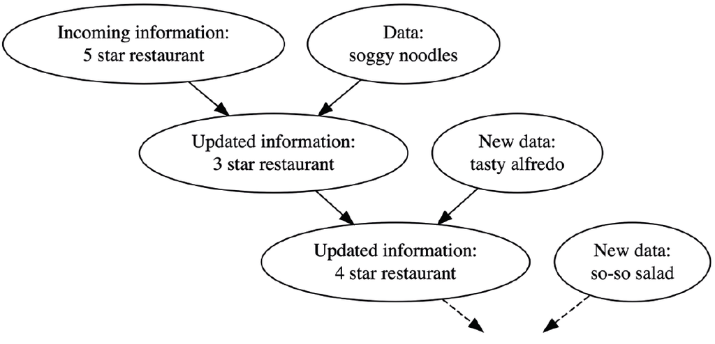

Figure 1.1: Your evolving knowledge about a restaurant.

Figure 1.1 captures the natural *Bayesian* knowledge-building process of acknowledging your preconceptions, using data to update your knowledge, and repeating. Such Bayesian approach can be applied to rigorous scientific research inquiries. You walk into such an inquiry with a context - you carry a degree of incoming or **prior** information based on previous research and experience. Naturally, it’s *in light of* this information that you interpret new **data**, weighing both in developing your updated or **posterior** information. You continue to refine this information as you gather new evidence (Figure 1.2).

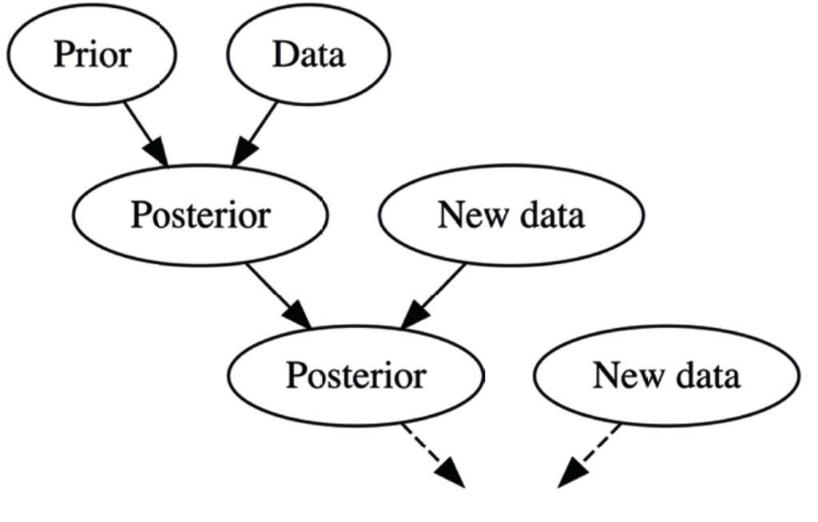

Figure 1.2: A Bayesian knowledge-building diagram.

The Bayesian philosophy represented in Figure 1.2 is the foundation of Bayesian statistics.

Throughout this book, you will build the methodology and tools you need to *implement* this philosophy in a rigorous data analysis.

Goals

- Learn to think like a Bayesian.
- Explore the foundations of a Bayesian data analysis and how they contrast with the frequentist alternative.
- Learn a little bit about the history of the Bayesian philosophy.

## 1.1 Thinking like a Bayesian

Bayesian approach is natural to knowledge building. **Frequentist** philosophy has traditionally dominated statistics, though. Although the distinction is sometimes hard to make in practice, and not one particular approach is used all the time, there is a need to illustrate the key differences between the logic behind the interpretation of Bayesian and frequentist analyses.

### 1.1.1 Quiz yourself

Take a quick quiz to assess your current inclinations. Just go with your gut.

1. When flipping a fair coin, we say that “the probability of flipping Heads is 0.5.” How do you interpret this probability?

a) If I flip this coin over and over, roughly 50% will be Heads.

b) Heads and Tails are equally plausible.

c) Both a and b make sense.

2. An election is coming up and a pollster claims that candidate A has a 0.9 probability of winning. How do you interpret this probability?

a) If we observe the election over and over, candidate A will win roughly 90% of the time.

b) Candidate A is much more likely to win than lose.

c) The pollster’s calculation is wrong. Candidate A will either win or lose, thus their probability of winning can only be 0 or 1.

3. Consider two claims. (1) Zuofu claims that he can predict the outcome of a coin flip. To test his claim, you flip a fair coin 10 times and he correctly predicts all 10. (2) Kavya claims that she can distinguish natural and artificial sweeteners. To test her claim, you give her 10 sweetener samples and she correctly identifies each. In light of these experiments, what do you conclude?

a) You’re more confident in Kavya’s claim than Zuofu’s claim.

b) The evidence supporting Zuofu’s claim is just as strong as the evidence supporting Kavya’s claim.

4. Suppose that during a recent doctor’s visit, you tested positive for a very rare disease. If you only get to ask the doctor one question, which would it be?

a) What’s the chance that I actually have the disease?

b) If in fact I don’t have the disease, what’s the chance that I would’ve gotten this positive test result?

Tally up your quiz score using the system below.

Problem 1. a = +1, b = +3, c = +2

Problem 2. a = +1, b = +3, c = +1

Problem 3. a = +3, b = +1

Problem 4. a = +3, b = +1

2+3+3+1 = 9

Totals from 9-12 indicate alignment with the Bayesian philosophy. Totals from 4-5 indicate that your current thinking is fairly frequentist.

6-8 means you’re in between, seeing the strength from both sides.

### 1.1.2 The meaning of probability

Probability theory is central to statistical analysis, but Bayesians and frequentists differ on the very definition of probability, just as illustrated by questions 1 and 2 in Section 1.1.1. It’s the interpretation that differs.

Interpreting probability

- In the Bayesian philosophy, a probability measures the **relative plausibility** of an event.
- The frequentist philosophy is so named for its interpretation of probability as the **long-run relative frequency** of a repeatable event.

Therefore, a Bayesian would say that “Heads and Tails are equally likely” and frequentist would say that “if we flip the coin over and over and over again, roughly 1/2 of these flips will be Heads”.

But, in an election example where a pollster claims that candidate A has a 0.9 probability of winning the upcoming election, the election is a one-time event and the long-run relative frequency concept of observing the election over and over is simply inapplicable. This shows the cracks within the frequentist interpretation. A strict frequentist would say that the pollster is wrong. A less extreme frequentist interpretation would say that in long-run *hypothetical* repetitions of the election, i.e., elections with similar circumstances, candidate A would win roughly 90% of the time, however awkward this may sound.

The election example is not rare: an event of interest is unrepeatable.

- Whether or not a potician wins an election,
- Whether or not it rains tomorrow,
- Whether or not humans will live on Mars one day, etc.

All of the above are one-time events.

Bayesian interpretation provides an alternative path by which to express the uncertainty of these events. A Bayesian for example would interpret “a 0.9 probability of winning” to mean that the relative plausibility of winning is high - the candidate is 9 times more likely to win than lose.

### 1.1.3 The Bayesian balancing act

Question 3 in Section 1.1.1 presented you with two scenarios (inspired by an example by [Berger (1984)](https://errorstatistics.files.wordpress.com/2016/04/berger-wolpert-1988.pdf)): (1) Zuofu claims that he can predict the outcomes of a coin flip and (2) Kavya claims that she can distinguish between natural and artificial sweeteners. Let’s agree here that Zuofu’s claim is absurd and Kavya’s claim is somewhat reasonable.

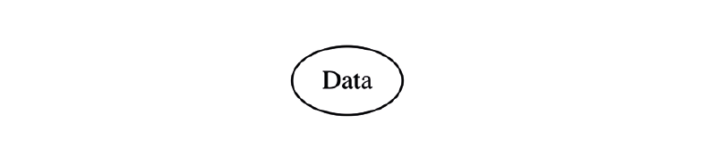

Figure 1.3: A frequentist knowledge-building diagram.

What does the **balance** between prior (information) and data mean? It’s the relative strength of each.

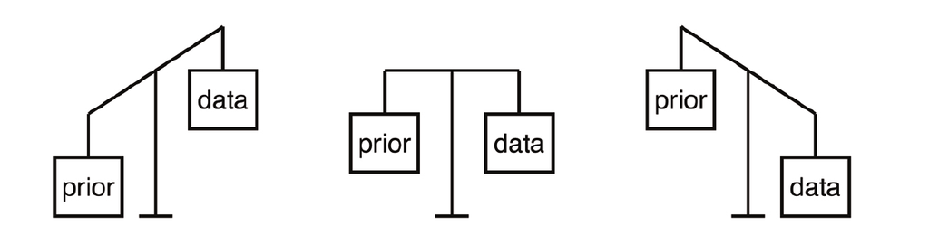

Figure 1.4: Bayesian analyses balance our prior experiences with new data. Depending on the setting, the prior is given more weight than the data (left), the prior and data are given equal weight (middle), or the prior is given less weight than the data (right).

- e.g.) We have a strong prior understanding that Zuofu is probably not likely to be a psychic, yet have very little data points (10 coin flips). Leftmost plot of Figure 1.4.
- e.g.) But if Zuofu had correctly predicted the outcome of like *10,000* coin flips, the strength of the data would far surpass that of our prior, leading to a posterior conclusion that perhaps Zuofu IS psychic after all (like the right plot in Figure 1.4).
- Allowing the posterior to balance out the prior and data is critical to the Bayesian knowledge-building process.
  - Little data → Our posterior can draw upon the power in our prior knowledge.
  - Collection of more data → The prior loses its influence.

This is natural in how people think. (In science, policy-making, and life overall.)

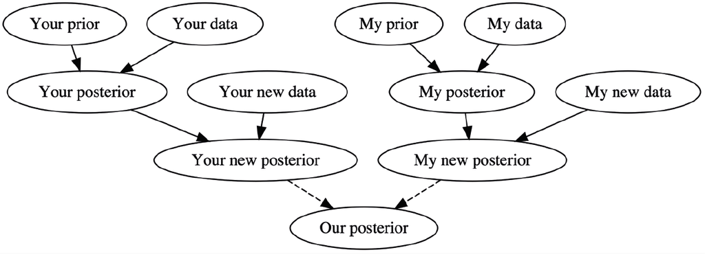

Figure 1.5: A two-person Bayesian knowledge-building diagram.

### 1.1.4 Asking questions

In question 4 of Section 1.1.1, you were asked what if you tested positive for a rare disease, what would you ask?: (a) what’s the chance that I actually have the disease?, or (b) what’s the chance that I would’ve gotten this positive result if I’m actually negative?

- **Bayesian** analysis: Assessment of uncertainty of the hypothesis in light of the observed data
  - Bayesian hypothesis: In light of the observed data, what’s the chance that the hypothesis is correct?
- **Frequentist** analysis: Assessment of uncertainty of the observed data in light of an assumed hypothesis.
  - Frequentist hypothesis: If in fact the hypothesis is incorrect, what’s the chance I’d have observed this, or even more extreme data?

Consider this scenario in Table 1.1.

Table 1.1: Disease status and test outcomes for 100 people.

|  | test positive | test negative | total |
| --- | --- | --- | --- |
| disease | 3 | 1 | 4 |
| no disease | 9 | 87 | 96 |
| total | 12 | 88 | 100 |

In a population of 100, only four people have the disease. Among the 96 without the disease, nine test positive and thus get misleading test results. Among the four with the disease, three test positive and thus get accurate test results.

Bayesian would ask “Given my positive test result, what’s the chance that I actually have the disease?” → Given the data, what’s the uncertainty in my hypothesis? → Given the data points observed, how much would they explain my hypothesis?

- Only 3 of the 12 people that tested positive have the actual disease.

Frequentist would ask “If I don’t actually have the disease, what’s the chance that I would’ve tested positive?” → What’s the chance I would have gotten this positive result if I’m not really positive? → If the hypothesis is wrong in the first place, what’s the chance I observe these data points?

- Only 9 people out of the total of 96 people who are actually negative will test positive.

9/96 frequentist probability calculation is similar in spirit to a **p-value**. (Chance of having observed data that are as or more extreme than ours if in fact our original hypothesis is incorrect.)

P-value is fading in importance because it is commonly being misinterpreted. (ASA “public safety announcement”)

It’s only natural to study the undertainty of a yet-unproven hypothesis (whether one has a rare disease), rather than the uncertainty of the data we have already observed (whether you incorrectly tested positive for the rare disease).

## 1.2 A quick history lesson

Bayesian rose to popularity recently. - Reverend Thomas Bayes - a statistician, minister, and philosopher (18th century) - *Month Hall* probability puzzle: Marilyn vos Savant came up with her Bayesian solution and was ridiculed by the readers. - Alan Turing’s cracking of Germany’s Enigma code used Bayesian methods. - John Tukey pioneered election-day predictions using Bayesian methods.

Why now?

$1$ **Advances in computing** - Bayesian applications require sophisticated computing resources that weren’t broadly available until the 1990s.

$2$ **Departure from tradition** - People are departing from long-ingrained tradition.

$3$ **Reevaluation of “subjectivity”** - “Subjective” is no longer a dirty word.

Bayesian timeline is described in Figure 1.6.

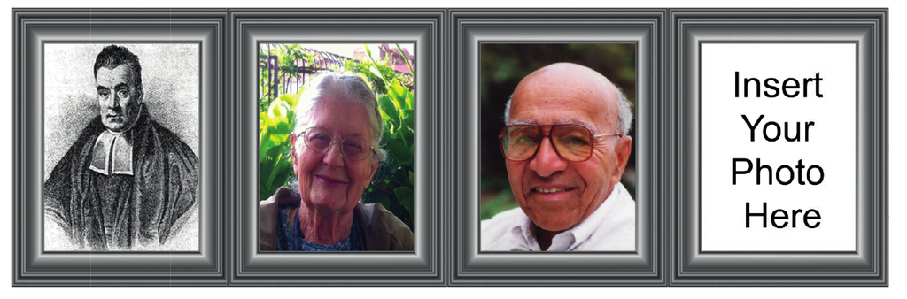

Figure 1.6: In order from left to right: Portrait of Thomas Bayes; photo of Arianna W. Rosenbluth; photo of David Blackwell at Berkely, California; you! (insert a photo of yourself).

## 1.3 A look ahead

Common thread throughout the book: building and analyzing Bayesian models for the behavior of some variable “$Y$.”

### 1.3.1 Unit 1: Bayesian foundations

> **Motivating question**

> How can we incorporate Bayesian thinking into a formal model of some variable of interest, $Y$?

Unit 1 give us the foundations of Bayesian analysis.

- *Bayes’ Rule*
- Build a few introductory but **fundamental Bayesian models**.
- These unique models are tied together in the broader **conjugate family**.
- Apply our Bayesian thinking with models tailored toward variables $Y$ of differing structures.
- e.g.) **Beta-binomial model**: Determine the probability that it rains tomorrow in Australia using data on **binary categorical variable** $Y$, whether or not it rains for each of the 1000 sampled days. (Figure 1.7 (a))
- e.g.) **Gamma-Poisson model**: Explore the rate of bald eagle sightings in Ontario, Canada using data on variable $Y$, the **counts** of eagles seen in each of 37 one-week observation periods. (Figure 1.7 (b))
- e.g.) **Normal-Normal model**: 3 p.m. temperature in Australia using data on the **bell-shaped** variable $Y$, temperatures on a sample of study days. (Figure 1.7 (c))[^2]

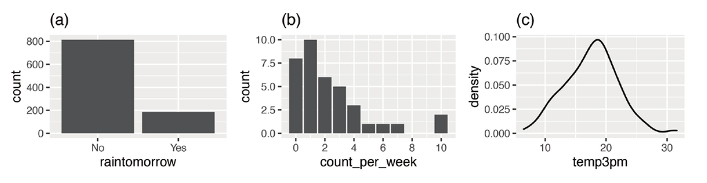

Figure 1.7: (a) Binomial output for the rain status of 1000 sampled days in Australia; (b) Poisson counts of bald eagles observed in 37 one-week observation periods; (c) Normally distributred 3 p.m. temperatures (in degrees Celsius) on 200 days in Australia.

### 1.3.2 Unit 2: Posterior simulation & analysis

> **Motivating questions**

> When our Bayesian models of $Y$ become too complicated to mathematically $specify$, how can we *approximate* them? And once we’ve either specified or approximated a model, how can we *make meaning* of and draw formal conclusions from it?

This part is concerned about the model approximation problem. What if we can’t generalize our basic models we learned in Unit 1? We might not be able to actually specify the model. When we can’t *know* something, we *approximate* it. We learn **Markov chain Monte Carlo** *simulation* techniques to *approximate* otherwise out-of-reach Bayesian models.

After specifying or approximating a Bayesian model, we must also be able to make meaning of and draw formal conclusions from the results. **Posterior analysis** is the process of asking “what does this all mean?!” and involves three major elements:

- posterior estimation
- hypothesis testing
- prediction

### 1.3.3 Unit 3: Bayesian regression & classification

> **Motivating question**

> We’re not always interested in the *lone* behavior of variable $Y$. We may want to understand the relationship between a set of $p$ potential **predictor variables** ($X_1, X_2, \dots, X_p$) and $Y$. How do we build a Bayesian model of this *relationship*? And how do we know whether ours is a *good* model?

Before Unit 3, we were only interested in a single variable $Y$. Once we have a grip on the response variable $Y$, we have a follow-up question: Can we **model** and **predict** the response variable based on predictors? For example, can we predict 3 p.m temperatures in Australia based on 9 a.m. tempearatures ($X_1$) and precise location ($X_2$)?

Bayesian modeling tools:

- Modeling and predicting a quantitative response variable $Y$ = regression task
- Modeling and predicting a categorical response variable $Y$ = classification task

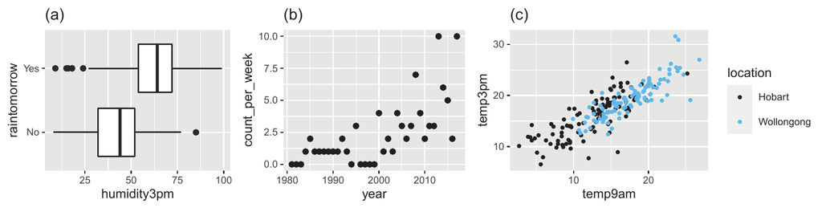

Figure 1.8: (a) Tomorrow’s rain vs. today’s humidity: classification problem; (b) the number of bald eagles over time: Poisson regression model problem of bald eagle counts increasing over time; (c) 3 p.m. vs 9 a.m. temperatures in two different Australian cities: Normal regression model problem between $Y$ and predictors $X_1$ and $X_2$.

We explore two approaches of classification here: (1) **logistic regression** (extension of the Unit 1 Beta-Binomial model) and (2) **Naive Bayes classification** (simplified extension of Bayes’ Rule).

### 1.3.4 Unit 4: Hierarchical Bayesian models

> Motivating question

> What if the structure of our data violates the independence assumptions behind the Unit 3 regression and classification models? Specifically, suppose we have multiple observations per random “group” in our dataset. How do we tweak our Bayesian models to not only acknowledge, but *harness* the structure?

Assumptions of **independence**: our data on the response and predictor variables $(Y,X_1,X_2, \dots , X_p)$ is a **random sample**.

| observation | y | x |
| --- | --- | --- |
| 1 | … | … |
| 2 | … | … |
| 3 | … | … |

We expand the flexibility of our Bayesian modeling by accommodating hierarchical, or **grouped data**.

| group | y | x |
| --- | --- | --- |
| A | … | … |
| A | … | … |
| B | … | … |
| B | … | … |
| B | … | … |

These are called the **hierarchical models**. We can appropriately reflect this data structure in our models to avoid doing the wrong thing, but also increase the power to detect the underlying trends in the relationships between $Y$ and $(X_1, X_2, \dots, X_p)$.

## 1.4 Chapter summary

We learned how to think like a Bayesian in Chapter 1.

Fundamental Bayesian knowledge-building process (Figure 1.2):

- Construct our **posterior knowledge** by balancing **information from our data** with our **prior knowledge**.
- As more and more data come in, we continue to **refine** this knowledge, which will fade the influence of original prior into the background.
- As more and more and data come in, two analysts that start out with opposing knowledge will eventually converge on the same posterior knowledge.

## 1.5 Exercises

**Exercise 1.1**

1. Identify possible prior information for Leslie’s chocolate milk story.

   Leslie though chocolate milk came from brown cows.
2. Identify the data that Leslie weighed against that incoming information in her chocolate milk story.

   There’s something called chocolate syrup. (New data that weighs against the prior.)
3. Identify the updated conclusion from the chocolate milk story.

   Updated conclusion is that chocolate milk is made from chocolate syrup.

**Exercise 1.2**

1. Write your own #BayesianTweet.

   Scientific process is Bayesian. #BayesianTweet
2. Write your own #FrequentistTweet.

   P-value hacking is an art. #FrequentistTweet

**Exercise 1.3**

I thought MDPI journals were pretty useful and reliable in my junior years in graduate school. That was my prior information. But as time went, there were social media posts and librarians warning against the MDPI journals for publishing too many articles and being near-predatory journals. Now I have a changed view of the journals.

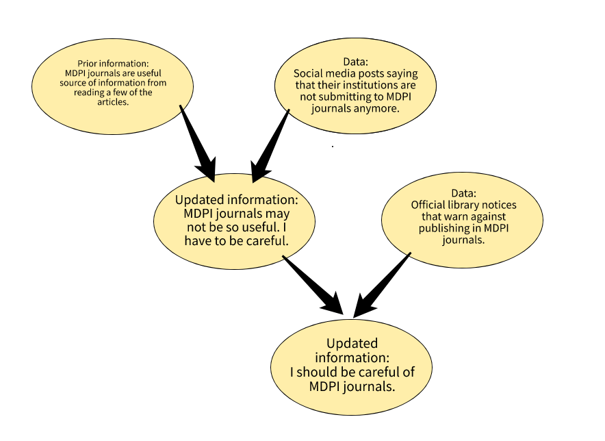

Figure 1.9: Exercise 1.3

**Exercise 1.4**

There was an instance where I convinced my friend to try Vietnamese food. She never liked foods with strong spice smell, but I changed her mind by introducing her to a really nice Vietnamese dining.

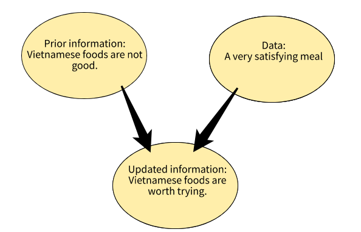

Figure 1.10: Exercise 1.4

**Exercise 1.5**

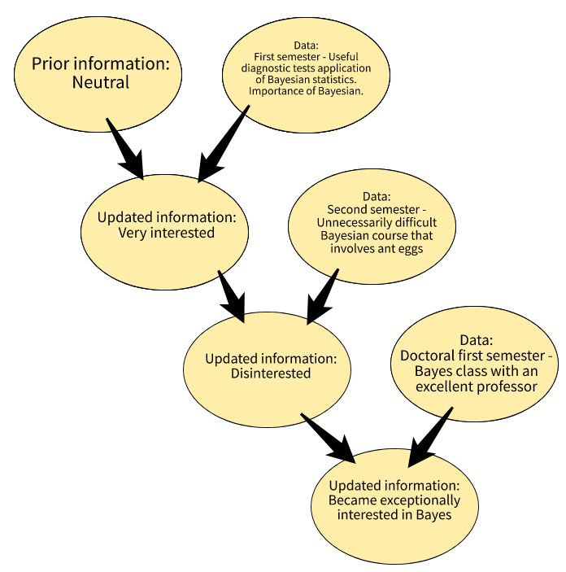

Figure 1.11: Exercise 1.5

**Exercise 1.6**

Data: I am qualified for the data science opening position.

Hypothesis: Am I going to get the job?

1. Frequentist thinking. What question is answered in testing hypothesis that you’ll be offered the position? If hypothesis is wrong, what are the chances of the data or more extreme data being observed? If I do not get the job, what is the probability of my qualifications or better qualifications being observed?
2. Repeat part (a) from the perspective of someone using Bayesian thinking. I know that I qualify for the job. But with my qualifications as scores, what are the chances of getting the job?
3. Which question would you rather have the answer to: the frequentist or the Bayesian? Explain your reasoning. I would rather have the Bayesian answer, because it’s more intuitive and natural to human mind.

**Exercise 1.7**

1. Identify a topic that you know about (e.g., a sport, a school subject, music).

   Bioinformatics
2. Identify a hypothesis about this subject.

   Bioinformatics is interesting.
3. How would your current expertise inform your conclusion about this hypothesis?

   It is true. There have been many setbacks and times I doubted myself, but it still holds true that bioinformatics is a fascinating subject.
4. Which framework are you employing here, Bayesian or frequentist?

   Bayesian.

**Exercise 1.8**

Your friend became interested in Bayesian statsitics. Explain the following to them:

1. Why is Bayesian statstics useful?

   Unlike frequentist statistics, it is more intuitive and natural and also it can describe one-time events in terms of plausibility.
2. What are the similarities in Bayesian and frequentist statistics?

   They have the same goals of proving a hypothesis.
[^1]: There is an extreme exception to this rule where 0 prior is assigned to a given scenario. If that’s the case, then no amount of data will change their mind. We will explore this specific situation in Chapter 4.
[^2]: These plots use the `weather_perth`, `bald_eagles`, and `weather_australia` data in the `bayesrules` packages. The weather datasets are subsets of the `weatherAUS` data in the `rattle` package. The eagles data was made available by Birds Canada (2018) and distributed by R for Data Science (2018).